# Blog Post Three

My research question is: “Identifying Bots in Social Media Comments.” The data was collected from Twitter, specifically from comments under Donald Trump’s tweet. There were originally 56k comments, but I’ve collected 304 so far.

```
Rows: 304
Columns: 5
$ author_id              <chr> "1452016545832443909", "1872496066467151872", "…
$ created_at             <chr> "2025-02-26T06:11:13.000Z", "2025-02-26T06:11:0…
$ text                   <chr> "@realDonaldTrump ...and this... https://t.co/4…
$ edit_history_tweet_ids <list> "1894631283030200625", "1894631241372098904", …
$ id                     <chr> "1894631283030200625", "1894631241372098904", "…
```

The dataset includes author, creation date, text, and newly added fields such as tweet_length, url_count, sentiment, and hashtag_count.

Performed sentiment analysis to find relationships between sentiment scores and new fields.

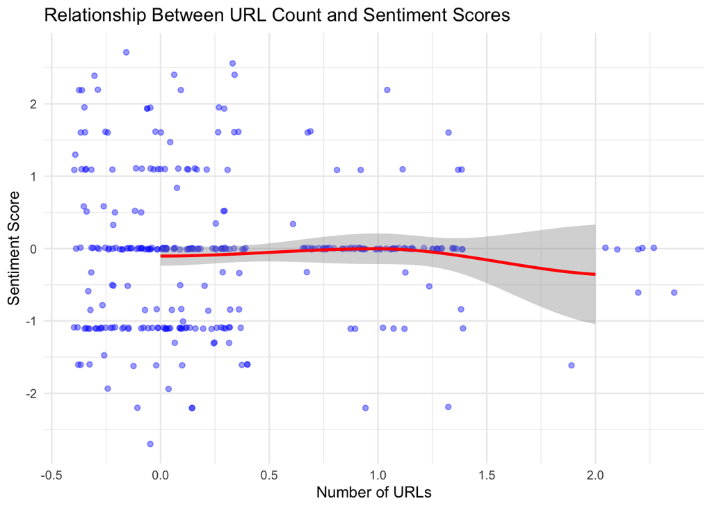

The plot shows that tweets containing more URLs often have neutral or negative sentiment. Let’s look at these tweets:

```
            author_id               created_at
1 1823320488946618368 2025-02-26T05:55:11.000Z
2 1823320488946618368 2025-02-26T05:55:03.000Z
3           154682511 2025-03-26T23:58:30.000Z
4           154682511 2025-03-26T23:58:09.000Z
5 1248456818457604097 2025-03-25T01:37:23.000Z
6 1759653315816673281 2025-03-23T10:32:27.000Z
7 1689622196899987456 2025-03-22T20:53:07.000Z
8 1871897881377996800 2025-03-22T10:00:12.000Z
                                                                                                                                                                                                                                                                                                            …
1                                                                                                                                                                                                                                                      @Ravious101 @realDonaldTrump https://t.co/iXDmwtxgqy …
2                                                                                                                                                                                                                                            @sully40272 @realDonaldTrump @TONYxTWO https://t.co/iXDmwtxgqy …
3                               @realDonaldTrump I hate the motherfucking President of the United States, but the rotten dog-felching bastard does get a lot of clicks, so I might as well use his fucking feed to promote my Go Fund Me to salvage what's left of my wasted life:\nhttps://t.co/zSwU2FGclI …
4                               @realDonaldTrump I hate the motherfucking President of the United States, but the rotten dog-felching bastard does get a lot of clicks, so I might as well use his fucking feed to promote my Go Fund Me to salvage what's left of my wasted life:\nhttps://t.co/zSwU2FGclI …
5 @realDonaldTrump #Trump SELF APPOINTED #SupremeLEADER 1,210,412 MILLION AMERICAN SOULs DEAD #FührerTrump #TrumpREGIME #TakesNOResponsibility #J6 #DonaldTrump #Rapist #Rape #ItIsWhatItIs #ACoupInPlainSight FAILED #ConvictedFELON #AboveTheLAW #ImpeachTrumpNOW #TrumpIsWEAK 🤡 https://t.co/HwrKgakA7w h…
```

[output cut: 21 more lines]

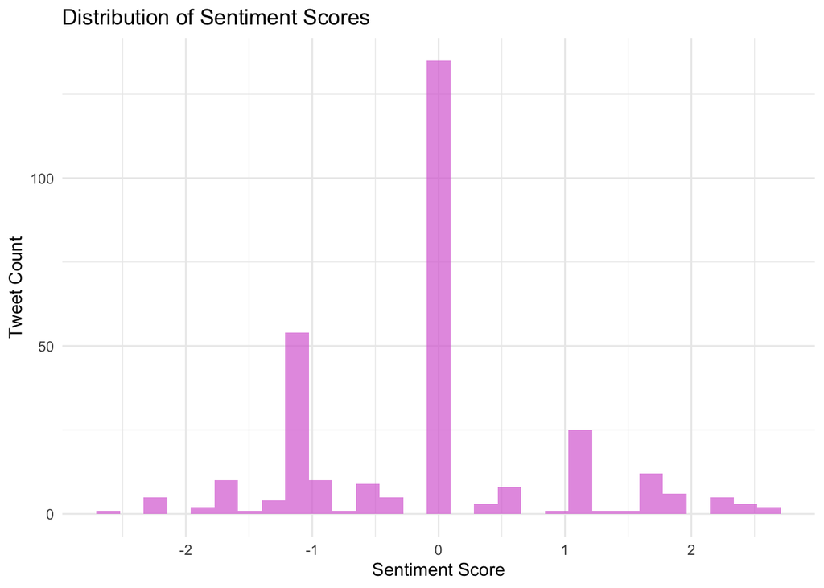

The histogram shows that many comments are neutral, but there are more negative comments than positive ones.

I am not sure if I can identify bots in social media comments because most research uses other data, like when the user was created, how frequently they post tweets, or how many followers they have. I found another dataset and thought maybe I could use it for supervised learning, but then I can’t use my own data or evaluate it because my data doesn’t contain labels for whether a user is a bot or not.